# NSE prioriteitenmatrix berekeningen

Dit is een [R Markdown](http://rmarkdown.rstudio.com) Notebook waarin voor de Nationale Student Enquete (NSE) prioriteitenmatrices worden berekend. Dit proces bestaat uit de volgende stappen:

1. Laden benodigde R-bibliotheken
2. Inladen NSE benchmark data
3. Selecteren van de juiste data
4. Exploratieve data analyse
5. Uitvoeren van de Relative Weight Analysis (RWA)
6. Visualiseren van resultaten
7. Exporteren van waardes

# 1. Laden R-bibliotheken

# 2. Inladen NSE benchmark bestand (clean data)

```r
NSEjaar = 2022 # Kies het NSE jaar om te analyseren
user <- Sys.getenv("USERNAME") #Vind de Windows username voor het instellen van padnaam waar csv-bestand staat
load(paste("C:/Users/",user,"/Stichting Hogeschool Utrecht/FCA-DA-P - Analytics/NSE/data/NSE", NSEjaar, " nse_benchmark_clean.RData", sep = ""))

rm(ind_exclusie) #Exclusie-vector is in deze analyse niet nodig
rm(vec_croho, vec_HO, vec_vorm) #Groepvectoren zijn onnodig, die worden vanwege herschaling opnieuw opgebouwd
head(nse_benchmark_clean,10)
```

|  | UniekNummer | Jaar | Weegfactor | BrinActueel | BrinNaamActueel | Brin | BrinNaam | CrohoActueel | CrohoNaamActueel | Croho | CrohoNaam | Locatie | CrohoSector | CrohoSectorNaam | BrinvolgnummerActueel | BrinVolgnummer | SoortHo | BaMa | Gemeentecode | Stedelijkheid | Landsdeel | Fixus | Decentraal | Bekostiging | Opleidingsvorm3 | Opleidingsvorm2 | TypeStudent | TEVREDENHEIDALGEMEEN_01 | TEVREDENHEIDALGEMEEN_02 | … |
| --- | --- | --- | --- | --- | --- | --- | --- | --- | --- | --- | --- | --- | --- | --- | --- | --- | --- | --- | --- | --- | --- | --- | --- | --- | --- | --- | --- | --- | --- | --- |
| 2 | 2.022e+10 | 2022 | 1.3011502 | 21RI | Hogeschool Leiden | 21RI | Hogeschool Leiden | 34396 | B Chemie | 34396 | B Chemie | Leiden | 4 | Techniek | 0 | 0 | 1 | 1 | 546 | 1 | 3 | 0 | 0 | 1 | 1 | 1 | 1 | 5 | 5 | … |
| 4 | 2.022e+10 | 2022 | 1.0416347 | 28DN | Hogeschool van Amsterdam | 28DN | Hogeschool van Amsterdam | 34092 | B Communication and Multimedia Design | 34092 | B Communication and Multimedia Design | Amsterdam | 4 | Techniek | 0 | 0 | 1 | 1 | 363 | 1 | 3 | 0 | 0 | 1 | 1 | 1 | 1 | 3 | 3 | … |
| 5 | 2.022e+10 | 2022 | 0.8706226 | 25KB | Hogeschool van Arnhem en Nijmegen | 25KB | Hogeschool van Arnhem en Nijmegen | 35025 | B Opleiding tot Leraar van de eerste graad in Lichamelijke Opvoeding | 35025 | B Opleiding tot Leraar van de eerste graad in Lichamelijke Opvoeding | Nijmegen | 1 | Onderwijs | 1 | 1 | 1 | 1 | 268 | 2 | 2 | 0 | 0 | 1 | 1 | 1 | 1 | 4 | 5 | … |
| 7 | 2.022e+10 | 2022 | 0.6446274 | 31FR | NHL Stenden Hogeschool | 31FR | NHL Stenden Hogeschool | 35514 | B International Teacher Education for Primary Schools (ITEps) | 35514 | B International Teacher Education for Primary Schools (ITEps) | Meppel | 1 | Onderwijs | 3 | 3 | 1 | 1 | 119 | 3 | 1 | 0 | 0 | 1 | 1 | 1 | 1 | 3 | 5 | … |
| 8 | 2.022e+10 | 2022 | 0.9345422 | 25BA | Christelijke Hogeschool Ede | 25BA | Christelijke Hogeschool Ede | 34116 | B Social Work | 34116 | B Social Work | Ede | 8 | Gedrag & Maatschappij | 0 | 0 | 1 | 1 | 228 | 2 | 2 | 0 | 0 | 1 | 2 | 2 | 1 | 4 | 4 | … |
| 9 | 2.022e+10 | 2022 | 1.2631518 | 02NR | Hotelschool The Hague | 02NR | Hotelschool The Hague | 34411 | B Hotel Management | 34411 | B Hotel Management | Amsterdam | 6 | Economie | 1 | 1 | 1 | 1 | 363 | 1 | 3 | 0 | 0 | 1 | 1 | 1 | 1 | 4 | 4 | … |
| 10 | 2.022e+10 | 2022 | 1.2333820 | 25KB | Hogeschool van Arnhem en Nijmegen | 25KB | Hogeschool van Arnhem en Nijmegen | 80149 | Ad Logistics Management | 80149 | Ad Logistics Management | Arnhem | 6 | Economie | 0 | 0 | 1 | 3 | 202 | 2 | 2 | 0 | 0 | 1 | 3 | 1 | 1 | 3 | 3 | … |
| 11 | 2.022e+10 | 2022 | 0.7577107 | 27UM | De Haagse Hogeschool | 27UM | De Haagse Hogeschool | 35158 | B Pedagogiek | 35158 | B Pedagogiek | 's-Gravenhage | 8 | Gedrag & Maatschappij | 1 | 1 | 1 | 1 | 518 | 1 | 3 | 0 | 0 | 1 | 1 | 1 | 1 | 2 | 3 | … |
| 14 | 2.022e+10 | 2022 | 0.8361912 | 22HH | Stichting Hogeschool Viaa | 22HH | Stichting Hogeschool Viaa | 34116 | B Social Work | 34116 | B Social Work | Zwolle | 8 | Gedrag & Maatschappij | 0 | 0 | 1 | 1 | 193 | 2 | 2 | 0 | 0 | 1 | 1 | 1 | 1 | 4 | NA | … |
| 17 | 2.022e+10 | 2022 | 0.9715137 | 25KB | Hogeschool van Arnhem en Nijmegen | 25KB | Hogeschool van Arnhem en Nijmegen | 34402 | B Commerciële Economie | 34402 | B Commerciële Economie | Nijmegen | 6 | Economie | 1 | 1 | 1 | 1 | 268 | 2 | 2 | 0 | 0 | 1 | 1 | 1 | 1 | 3 | 3 | … |

# 3. Data selectie & definitie

Voor deze analyse zullen de volgende vragen als uitkomst- en voorspellende variabelen gebruikt worden:

Uitkomst: Vraag 01 Voorspellende variabelen: 02, 03, 06, 07, 08, 09, 10, 12

Dit is in overleg met de business besloten. Vraag 01 wordt traditioneel gezien als uitkomst-maat. Vraag 02 t/m 12 zijn algemene vragen (detailvragen zijn voor nu out-of-scope), waarbij vragen 04, 05 en 11 afvallen omdat zij slechts aan een deel van de studenten gesteld zijn.

```r
vec_rwauitkomst <- str_NSEvragen[1]            # Kies vraag die de uitkomst variabele zal zijn
vec_rwavariabelen <- str_NSEvragen[c(2,3,6:10,12)] # Kies vragen die voorspellende variabelen zijn
vec_rwavragen <- c(vec_rwauitkomst, vec_rwavariabelen) # Alle vragen die gebruikt worden in de RWA

str_NSEvragen_kort <- substr(str_NSEvragen, nchar(str_NSEvragen)-1, nchar(str_NSEvragen)) #Afkortingen voor vragen
```

Alleen studenten van de Hogeschool Utrecht worden gebruikt in deze data analyse.

```r
HUscores <- nse_benchmark_clean[nse_benchmark_clean$BrinNaamActueel == "Hogeschool Utrecht",c("UniekNummer", "Weegfactor", "CrohoNaamActueel", "SoortHo", "BaMa", "Opleidingsvorm3",vec_rwavragen)]

rm(nse_benchmark_clean)
```

De weegfactor die bij het benchmarkbestand wordt meegeleverd corrigeert voor verschillen in responspercentages tussen crohos en instelling. De weegfactor is hiermee een frequentietelling, d.w.z.: hoe vaak moet ik de betreffende meting meetellen, en heeft in deze HU dataset een waarde tussen 0.450 en 3.386. Om deze weegfactor correct in correlatie-berekeningen mee te nemen is het nodig de dataset te herschalen met een factor 1000. Door te herschalen via een factor 1000 (d.w.z. een weegfactor van 0.450 wordt 450, en 3.386 wordt 3386) is het mogelijk om de oorspronkelijke dataset opnieuw op te bouwen waarin observaties worden vermeerderd met deze herschaalde weegfactor. Eén meting met een herschaalde weegfactor 450 komt dan in de herschaalde data 450 maal voor, enzovoorts.

Let op: onderstaande bewerking is memory-heavy (~1.8 Gb bij factor = 1000)

```r
factor = 1000;
HUscores_hers <- HUscores[rep(seq(nrow(HUscores)), round(HUscores$Weegfactor*factor)),]
rm(HUscores)
```

```r
nrow_nieuw <- sum(complete.cases(HUscores_hers[,vec_rwavragen]))
nrow_oud <- nrow(HUscores_hers)
HUscores_hers <- HUscores_hers[complete.cases(HUscores_hers[,vec_rwavragen]), ]

cat("In deze stap zijn het volgende aantal rijen weggefilterd:", (nrow_oud-nrow_nieuw),"(d.w.z.",round((nrow_oud-nrow_nieuw)/nrow_oud*100), "% van het totaal).")
```

```
## In deze stap zijn het volgende aantal rijen weggefilterd: 327756 (d.w.z. 3 % van het totaal).
```

Definieer verschillende dwarsdoorsnedes (croho, vorm en typeHO)

```r
#Maak voor elke croho een logische vector
vec_croho <- vector(mode = "list", Ncrohos)
for (h in 1:Ncrohos)
{
  vec_croho[[h]] <- HUscores_hers$CrohoNaamActueel == NSEcrohos[h]
}
vec_croho[[Ncrohos-1]] <- rep(TRUE, nrow(HUscores_hers));

#Maak voor het instituut archimdes een logische vector en voeg deze data in op de laatste index
vec_instituut <- HUscores_hers$CrohoNaamActueel %in% NSEcrohos[c(44:57,80:88)]
vec_croho[[Ncrohos]] <- vec_instituut

#Maak voor elke vorm een logische vector
vec_vorm <- vector(mode = "list", int_vorm)
for (i in 1:int_vorm)
{
  vec_vorm[[i]]<- HUscores_hers$Opleidingsvorm3 == NSEvormen[i]
}
#Voeg nu een extra lijst toe die alle vormen meeneemt (totaal-berekening)
vec_vorm[[int_vorm]] <- rep(TRUE, nrow(HUscores_hers))

#Maak voor elke HOtype een logische vector
vec_HO <- vector(mode = "list", NHO)
for (j in 1:NHO)
{
  vec_HO[[j]]<- HUscores_hers$BaMa == NSEHOtypes[j]
}
#En extra lijst toevoegen voor HU-totaal
vec_HO[[NHO]] <- rep(TRUE, nrow(HUscores_hers))
```

# 4. Exploratieve data analyse

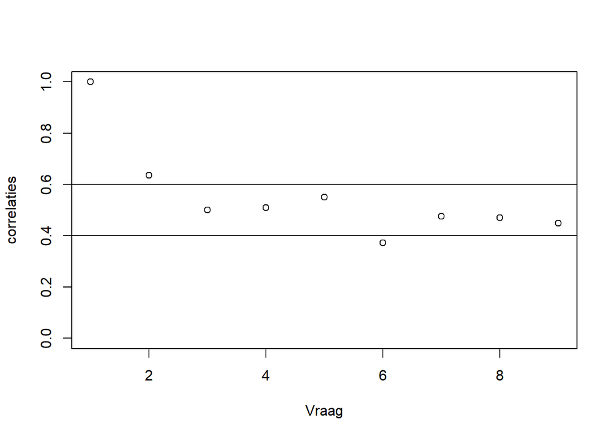

```r
correlaties = NA
for (i in 1:length(vec_rwavragen))
{
  correlaties[i] <- cor.test(HUscores_hers[,vec_rwavragen[1]], HUscores_hers[,vec_rwavragen[i]], method = "spearman")$estimate
}
plot(1:length(vec_rwavragen),correlaties, xlab = 'Vraag', ylim = c(0,1)); abline(h=0.6); abline(h=0.4)
```

Conclusie: Het merendeel van de NSE vragen zijn ten minste matig (0.6 > R > 0.4) gecorreleerd met de algemene vraag ‘Hoe tevreden ben jij met je opleiding in het algemeen?’ (= vraag 1 uit NSE).

Hoe zit het nu met correlaties tússen de voorspellende vragen?

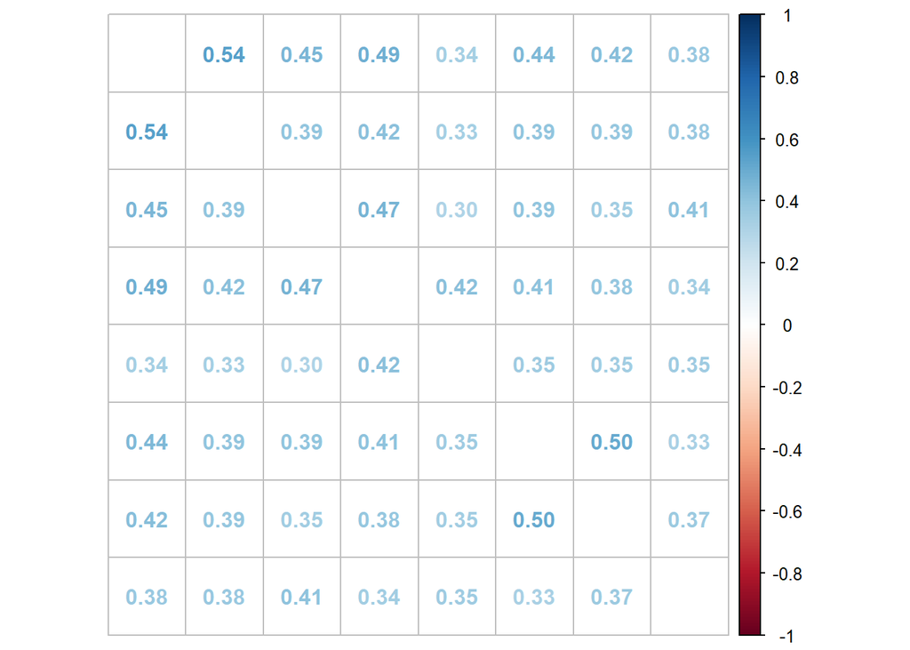

```r
mcoll <- cor(HUscores_hers[,vec_rwavariabelen])
colnames(mcoll) <- str_NSEvragen_kort[vec_rwavariabelen]
rownames(mcoll) <- str_NSEvragen_kort[vec_rwavariabelen]
corrplot(mcoll, method = "number", diag = FALSE); rm(mcoll)
```

De bovenstaande correlatie-matrix laat de correlatie tussen elke voorspellende variabele combinatie zien. Voor een heel aantal combinaties is deze matig (0.6 > R > 0.4) gecorreleerd, waarbij vraag 02 en 03 het sterkst gecorreleerd is met R = 0.54.

Conclusie: er sprake van [multicollineariteit](https://en.wikipedia.org/wiki/Multicollinearity) tussen de verschillende voorspellende variabelen, en deze vragen zijn dus niet onafhankelijk van elkaar. Dit maakt het toepassen en interpreteren van een ‘standaard’ statistisch model (bijv. multiple regressie) ingewikkeld.

# 5. Relative weight analysis

Om de bijdrage van een aantal voorspellende variabelen op een uitkomstmaat te modelleren, wordt normaliter een multiple regressie gebruikt. De aanname bij multiple regressie is dat de voorspellende variabelen onafhankelijk van elkaar zijn (d.w.z. geen of minimale correlatie). In dit geval zijn de voorspellende variabelen zwak tot matig met elkaar gecorreleerd, en kan een multiple regressie dus niet eenvoudig ingezet worden.

Voor meer informatie over Relative weight analysis in R: [<https://github.com/martinctc/rwa>](https://github.com/martinctc/rwa)

Hierin is ook terug te vinden dat vragenlijstdata valide is als input voor een RWA.

```r
cat("Er wordt nu een RWA model berekend met vraag", vec_rwauitkomst , "als onafhankelijke variabele.\nEen RWA model probeert om de onafhankelijke variabele te verklaren door gewichten toe te kennen aan een aantal vooraf gekozen afhankelijke variabelen. Voor dit model zijn alleen studenten meegenomen die voor zowel voor de onafhankelijke variabele én alle afhankelijke variabelen ingevulde responses bevatten (complete gevallen).\nDe volgende lijst aan vragen zijn de voorspellende variabelen: \n", vec_rwavariabelen)
```

```
## Er wordt nu een RWA model berekend met vraag TEVREDENHEIDALGEMEEN_01 als onafhankelijke variabele.
## Een RWA model probeert om de onafhankelijke variabele te verklaren door gewichten toe te kennen aan een aantal vooraf gekozen afhankelijke variabelen. Voor dit model zijn alleen studenten meegenomen die voor zowel voor de onafhankelijke variabele én alle afhankelijke variabelen ingevulde response…
## De volgende lijst aan vragen zijn de voorspellende variabelen:
##  TEVREDENHEIDALGEMEEN_02 TEVREDENHEIDALGEMEEN_03 TEVREDENHEIDALGEMEEN_06 TEVREDENHEIDALGEMEEN_07 TEVREDENHEIDALGEMEEN_08 TEVREDENHEIDALGEMEEN_09 TEVREDENHEIDALGEMEEN_10 TEVREDENHEIDALGEMEEN_12
```

```r
#Pre-alloceer objecten die in loop gevuld gaan worden
rwa_bijdrage <- array(NA, dim = c(int_vorm, NHO, Ncrohos, length(vec_rwavariabelen)))
rwa_scores   <- array(NA, dim = c(int_vorm, NHO, Ncrohos, length(vec_rwavariabelen)))
rwa_R2       <- array(NA, dim = c(int_vorm, NHO, Ncrohos))
N            <- array(NA, dim = c(int_vorm, NHO, Ncrohos))
#Maak functie die gewogen gemiddelde berekend
fun_gewgem   <- function(x, w) weighted.mean(x, w)

#Bereken voor elke dwarsdoorsnede de N, de score en bijdrage
#!Let op: deze loop draait circa 20 minuten! (voor het uitvoeren van deze HTML is deze)
ind_croho = 94 # voor HTML voorbeeld 1 croho hardcoded gekozen

  for (ind_ho in 1:NHO)
  {
    for (ind_vorm in 1:int_vorm)
    {
      # Data-doorsnede selecteren
      HUdoorsnede <- HUscores_hers[vec_vorm[[ind_vorm]]&
                                     vec_HO[[ind_ho]]&
                                     vec_croho[[ind_croho]],]

      # Groepsgroote (N) berekenen
      N[ind_vorm,ind_ho,ind_croho] <-length(unique(HUdoorsnede$UniekNummer))

      # Als N < 10 of variantie = 0, dan geen rwa uitvoeren (=randvoorwaarden RWA)
      if (N[ind_vorm,ind_ho,ind_croho] < 10 | var(HUdoorsnede$TEVREDENHEIDALGEMEEN_01) == 0)
      {
        next #Sla groep over en ga naar volgende iteratie
      }
      else
      {
        #Voor rwa berekening
        rwa_resultaten <- HUdoorsnede %>%
          rwa(outcome    = vec_rwauitkomst,
              predictors = vec_rwavariabelen,
              applysigns = TRUE)
        #Bijdrage aan de totaalscore
        rwa_bijdrage[ind_vorm,ind_ho,ind_croho,] <- rwa_resultaten$result$Sign.Rescaled.RelWeight
        #Gemiddelde score per vraag
        rwa_scores[ind_vorm,ind_ho,ind_croho,]   <- unlist(lapply(HUdoorsnede[,vec_rwavragen[2:9]],
                                                                  fun_gewgem,
                                                                  HUdoorsnede$Weegfactor))
        #Totale verklaarde variantie (R^2)
        rwa_R2[ind_vorm,ind_ho,ind_croho]        <- rwa_resultaten$rsquare
      } #Sluiten rwa loop
    } #Sluiten vorm-loop
  } #Sluiten type HO loop

rm(HUdoorsnede)
```

# 6. Visualiseren resultaat

Een prioriteitenmatrix laat het gewicht van een voorspellende variabele (x-as) zien ten opzichte van de gemiddelde score op deze variabele (y-as).

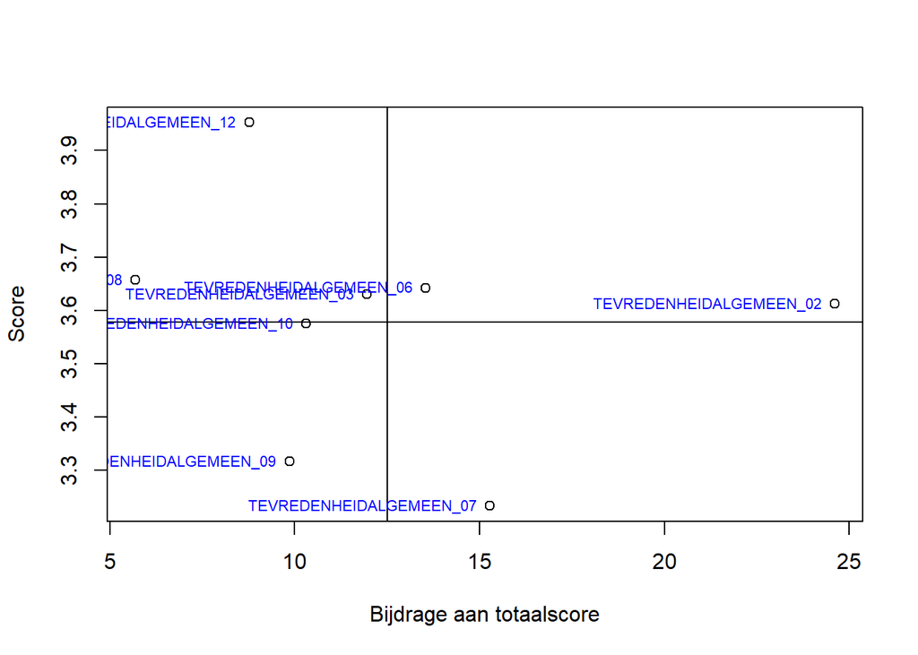

```r
ind_vorm = 4
ind_ho = 4
ind_croho = 94

rwa_scores_gem   <- mean(rwa_scores[ind_vorm,ind_ho,ind_croho,])
rwa_bijdrage_gem <- mean(rwa_bijdrage[ind_vorm,ind_ho,ind_croho,])

plot(rwa_bijdrage[ind_vorm,ind_ho,ind_croho,],
     rwa_scores[ind_vorm,ind_ho,ind_croho,],
     xlab = 'Bijdrage aan totaalscore',
     ylab = 'Score' );
abline(h=rwa_scores_gem, #Gemiddelden horizontale en verticale lijnen zodra de matrix vorm krijgt
       v=rwa_bijdrage_gem,
       col="black")
text(rwa_bijdrage[ind_vorm,ind_ho,ind_croho,], #Toevoegen nummer van vraag aan plot
     rwa_scores[ind_vorm,ind_ho,ind_croho,],
     vec_rwavariabelen,
     cex=0.7,
     pos=2,
     col="blue")
```

# 7. Exporteren waardes

```r
prioriteitenmatrix <- data.frame()
for(ind_croho in 1:Ncrohos)
{
  for (ind_ho in 1:NHO)
  {
    for (ind_vorm in 1:int_vorm)
    {
      tmp <- data.frame(Opleidingsvorm3 = NSEvormen[ind_vorm],
                        BaMa            = NSEHOtypes[ind_ho],
                        Croho           = NSEcrohos[ind_croho],
                        NSEvragen       = vec_rwavariabelen,
                        RWAscores       = rwa_scores[ind_vorm,ind_ho,ind_croho,],
                        RWAbijdrage     = rwa_bijdrage[ind_vorm,ind_ho,ind_croho,],
                        N               = N[ind_vorm,ind_ho,ind_croho],
                        Rsquared        = rwa_R2[ind_vorm,ind_ho,ind_croho],
                        Afnamejaar      = NSEjaar)
      prioriteitenmatrix <- rbind(prioriteitenmatrix, tmp);
    }
  }
}
rm(tmp)
#Weglaten NA waardes
prioriteitenmatrix <- prioriteitenmatrix[!is.na(prioriteitenmatrix$RWAscores),]
```

```r
# write.csv(prioriteitenmatrix,file = paste("~/researchdrive/M21033303_DenA (Projectfolder)/DA_Onderzoek/", NSEjaar, "nse/data_uit/NSEprioriteitentabel", NSEjaar, ".csv", sep = ""))
```